# Exam 3

Emily Tyger | emt5337

12/13/2020

```r
library(RSQLite)
library(ggplot2)

delay.con <- dbConnect(RSQLite::SQLite(),
                       dbname = "~/Downloads/dataverse_files/AirlineDelay.sqlite3")
```

1. What was the most popular airline in 2000?
2. How many flights did that airline record in 2000?

```r
popair = dbGetQuery(delay.con,
               "SELECT COUNT(*), UniqueCarrier
               FROM AirlineDelay
               WHERE Year=2000
               GROUP BY UniqueCarrier
               ORDER BY COUNT(*) DESC LIMIT 10 ")
# View(popair)
```

3. Since 2005, which airline has undertaken the longest flights (time) on average?

```r
longflight = dbGetQuery(delay.con,
              "SELECT AVG(ActualElapsedTime) AS Elapsedtime, UniqueCarrier
              FROM AirlineDelay
              WHERE (ActualElapsedTime IS NOT 'NA') AND Year >= 2005
              GROUP BY UniqueCarrier
              ORDER BY Elapsedtime DESC LIMIT 10")
# View(longflight)
```

4. How many flights used a carrier with an E in the name? (e.g. XE)

```r
Ecarriers = dbGetQuery(delay.con,
               "SELECT COUNT(*), UniqueCarrier
           FROM AirlineDelay
           WHERE UniqueCarrier LIKE '%E%'
           GROUP BY UniqueCarrier ")
# View(Ecarriers)
```

5. For each of the 22 years in the dataset, how many of the tail codes are listed as NA? Paste the table of values.

```r
tailNAs = dbGetQuery(delay.con,
                      "SELECT COUNT(*), Year
                      FROM AirlineDelay
                      WHERE (TailNum IS 'NA') AND Year >= 2000
                      GROUP BY Year")
#View(tailNAs)
```

6. Which of the following Origin->Destination combinations have the largest (average) Arrival delays?

```r
largedelay = dbGetQuery(delay.con,
                         "SELECT COUNT(*), Origin || Dest as combined,
                         AVG(ArrDelay) as Avg_ArrDelay
                         FROM AirlineDelay
                         GROUP BY combined
                         ORDER BY Avg_ArrDelay DESC")
# View(largedelay)
```

7. Are flights being given more (average) time to reach their destination for later years? Use ggplot to display the trend for each year in the dataset, and upload the image.

```r
Flighttimebyyear = dbGetQuery(delay.con,
                              "SELECT Year, AVG(CRSElapsedTime) as Time
                              FROM AirlineDelay
                              GROUP BY Year")
```

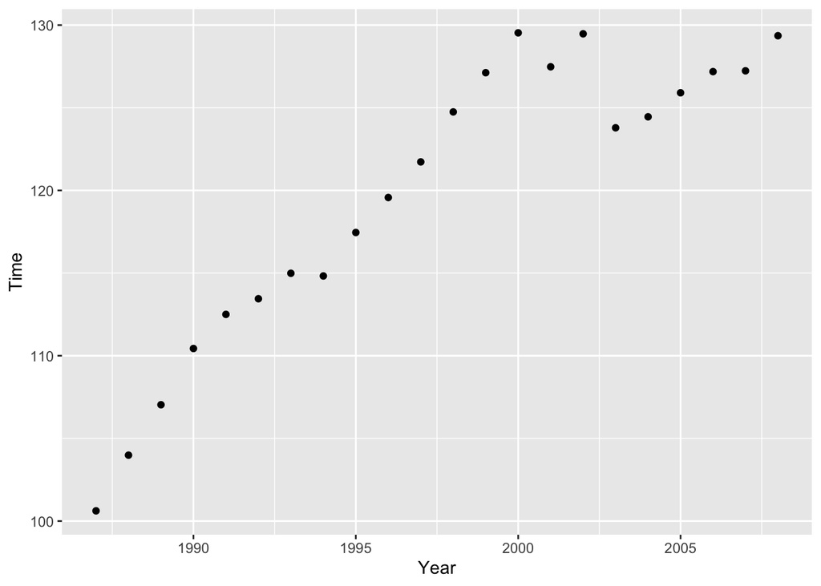

```r
# View(Flighttimebyyear)
Flighttimebyyear = Flighttimebyyear[1:22,]

timeyearplot = ggplot(Flighttimebyyear, aes(x = Year, y = Time)) +
  geom_point()
timeyearplot
```

```r
ggsave("timeyearplot.png", plot = timeyearplot)
```

8. As a possible explanation, are the average flight distances getting longer every year? Use ggplot to display the trend for each year in the dataset, and upload the image.

```r
Flightdistancebyyear = dbGetQuery(delay.con,
                              "SELECT Year, AVG(Distance) as Distance
                              FROM AirlineDelay
                              GROUP BY Year")
```

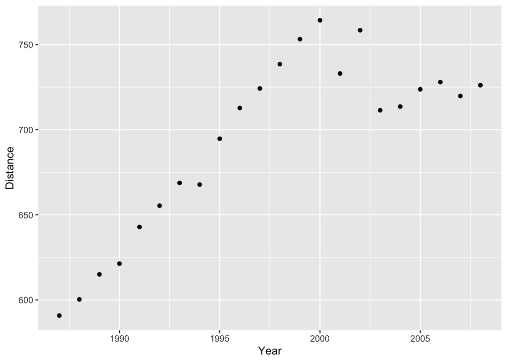

```r
# View(Flightdistancebyyear)
Flightdistancebyyear = Flightdistancebyyear[1:22,]

distyearplot = ggplot(Flightdistancebyyear, aes(x = Year, y = Distance)) +
  geom_point()
distyearplot
```

```r
ggsave("distyearplot.png", plot = distyearplot)
```

9. Compute the correlation (aka correlation coefficient) between the two quantities in the question above? I.e. the correlation between 1) The average flight distance for each year 2) The average scheduled time per flight for each year

```r
temp1 = list(Flighttimebyyear, Flightdistancebyyear)
timedist <- Reduce(function(d1,d2) merge(d1,d2, by = c("Year"), all.x = TRUE), temp1)
# View(timedist)

corr = cor.test(timedist$Year, timedist$Distance)
corr
```

```
##
##  Pearson's product-moment correlation
##
## data:  timedist$Year and timedist$Distance
## t = 6.5474, df = 20, p-value = 2.22e-06
## alternative hypothesis: true correlation is not equal to 0
## 95 percent confidence interval:
##  0.6200032 0.9252460
## sample estimates:
##       cor
## 0.8257593
```

10. Find the total number of delayed arrivals for each year (ArrDelay>0). Find the total number of delayed departures for each year (DepDelay>0). Fit a linear model between the two quantities and give the equation of the line (intercept and slope)

```r
delArr = dbGetQuery(delay.con,
                    "SELECT COUNT(*) as arrival, Year
                    FROM AirlineDelay
                    WHERE ArrDelay > 0
                    GROUP BY Year")
# View(delArr)
delArr = delArr[1:22,]

delDep = dbGetQuery(delay.con,
                    "SELECT COUNT(*) as departure, Year
                    FROM AirlineDelay
                    WHERE DepDelay > 0
                    GROUP BY Year")
# View(delDep)
delDep = delDep[1:22,]

temp2 = list(delArr, delDep)
delays <- Reduce(function(d1,d2) merge(d1,d2, by = c("Year"), all.x = TRUE), temp2)
# View(delays)

model = lm(Year ~ arrival + departure, data = delays)
model
```

```
##
## Call:
## lm(formula = Year ~ arrival + departure, data = delays)
##
## Coefficients:
## (Intercept)      arrival    departure
##   1.991e+03   -3.779e-06    7.054e-06
```